[figure not shown]

# Introduction

Les services de streaming ont examiné les moyens de catégoriser la musique pour permettre des recommandations personnalisées. Aujourd’hui, nous examinerons les données compilées par un groupe de recherche connu sous le nom de The Echo Nest. Notre objectif est de parcourir cet ensemble de données et de classer les chansons comme étant soit « Hip-Hop » ou « Rock » - le tout sans en écouter une seule nous-mêmes.

# 1. Preparer notre dataset

Nettoyer nos données, effectuer une visualisation exploratoire des données et à utiliser la réduction des fonctionnalités dans le but d’alimenter nos données grâce à des algorithmes d’apprentissage automatique simples, tels que des arbres de décision et une régression logistique.

```python
import pandas as pd

# Read in track metadata with genre labels
tracks = pd.read_csv('datasets/fma-rock-vs-hiphop.csv')

# Read in track metrics with the features
echonest_metrics = pd.read_json('datasets/echonest-metrics.json', precise_float=True)

# Merge the relevant columns of tracks and echonest_metrics
echo_tracks = echonest_metrics.merge(tracks[['genre_top', 'track_id']], on='track_id')

# Inspect the resultant dataframe
echo_tracks.info()
```

```
<class 'pandas.core.frame.DataFrame'>
Int64Index: 4802 entries, 0 to 4801
Data columns (total 10 columns):
 #   Column            Non-Null Count  Dtype
---  ------            --------------  -----
 0   track_id          4802 non-null   int64
 1   acousticness      4802 non-null   float64
 2   danceability      4802 non-null   float64
 3   energy            4802 non-null   float64
 4   instrumentalness  4802 non-null   float64
 5   liveness          4802 non-null   float64
 6   speechiness       4802 non-null   float64
 7   tempo             4802 non-null   float64
 8   valence           4802 non-null   float64
 9   genre_top         4802 non-null   object
dtypes: float64(8), int64(1), object(1)
memory usage: 412.7+ KB
```

Nous voulons généralement éviter d’utiliser des variables qui ont de fortes corrélations les unes avec les autres - évitant ainsi la redondance des fonctionnalités - pour plusieurs raisons:

Pour garder le modèle simple et améliorer l’interprétabilité (avec de nombreuses fonctionnalités, nous courons le risque de surajustement). Lorsque nos ensembles de données sont très volumineux, l’utilisation de moins de fonctionnalités peut considérablement accélérer notre temps de calcul.

```python
# Create a correlation matrix
corr_metrics = echo_tracks.corr()
corr_metrics.style.background_gradient()
```

|  | track_id | acousticness | danceability | energy | instrumentalness | liveness | speechiness | tempo | valence |
| --- | --- | --- | --- | --- | --- | --- | --- | --- | --- |
| track_id | 1.000000 | -0.372282 | 0.049454 | 0.140703 | -0.275623 | 0.048231 | -0.026995 | -0.025392 | 0.010070 |
| acousticness | -0.372282 | 1.000000 | -0.028954 | -0.281619 | 0.194780 | -0.019991 | 0.072204 | -0.026310 | -0.013841 |
| danceability | 0.049454 | -0.028954 | 1.000000 | -0.242032 | -0.255217 | -0.106584 | 0.276206 | -0.242089 | 0.473165 |
| energy | 0.140703 | -0.281619 | -0.242032 | 1.000000 | 0.028238 | 0.113331 | -0.109983 | 0.195227 | 0.038603 |
| instrumentalness | -0.275623 | 0.194780 | -0.255217 | 0.028238 | 1.000000 | -0.091022 | -0.366762 | 0.022215 | -0.219967 |
| liveness | 0.048231 | -0.019991 | -0.106584 | 0.113331 | -0.091022 | 1.000000 | 0.041173 | 0.002732 | -0.045093 |
| speechiness | -0.026995 | 0.072204 | 0.276206 | -0.109983 | -0.366762 | 0.041173 | 1.000000 | 0.008241 | 0.149894 |
| tempo | -0.025392 | -0.026310 | -0.242089 | 0.195227 | 0.022215 | 0.002732 | 0.008241 | 1.000000 | 0.052221 |
| valence | 0.010070 | -0.013841 | 0.473165 | 0.038603 | -0.219967 | -0.045093 | 0.149894 | 0.052221 | 1.000000 |

## 3. Normalisation des données

Comme nous n’avons pas trouvé de corrélations particulièrement fortes entre nos caractéristiques, nous pouvons plutôt utiliser une approche commune pour réduire le nombre de caractéristiques appelée analyse en composantes principales (APC).

L’APC fait pivoter les données le long de l’axe de variance la plus élevée, ce qui nous permet de déterminer la contribution relative de chaque caractéristique de nos données à la variance entre les classes.

```python
# Define our features
features = echo_tracks.drop(columns=['genre_top', 'track_id'])

# Define our labels
labels = echo_tracks['genre_top']

# Import the StandardScaler
from sklearn.preprocessing import StandardScaler

# Scale the features and set the values to a new variable
scaler = StandardScaler()
scaled_train_features = scaler.fit_transform(features)
```

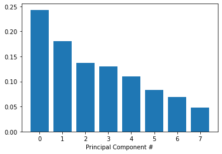

```python
# This is just to make plots appear in the notebook
%matplotlib inline

# Import our plotting module, and PCA class
import matplotlib.pyplot as plt
from sklearn.decomposition import PCA

# Get our explained variance ratios from PCA using all features
pca = PCA()
pca.fit(scaled_train_features)
exp_variance = pca.explained_variance_ratio_

# plot the explained variance using a barplot
fig, ax = plt.subplots()
ax.bar(range(pca.n_components_), exp_variance)
ax.set_xlabel('Principal Component #')
```

Malheureusement, il ne semble pas y avoir de coude clair dans ce diagramme, ce qui signifie qu’il n’est pas simple de trouver le nombre de dimensions intrinsèques en utilisant cette méthode.

Nous pouvons également examiner le diagramme de variance expliquée cumulative pour déterminer combien de caractéristiques sont nécessaires pour expliquer, disons, environ 85% de la variance (les seuils sont quelque peu arbitraires ici, et généralement décidés par des « règles empiriques »). Une fois que nous avons déterminé le nombre approprié de composants, nous pouvons effectuer un PCA avec autant de composants, réduisant idéalement la dimensionnalité de nos données.

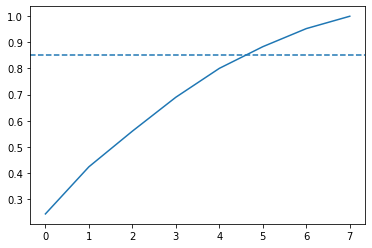

```python
# Import numpy
import numpy as np

# Calculate the cumulative explained variance
cum_exp_variance = np.cumsum(exp_variance)

# Plot the cumulative explained variance and draw a dashed line at 0.85.
fig, ax = plt.subplots()
ax.plot(cum_exp_variance)
ax.axhline(y=0.85, linestyle='--')

# choose the n_components where about 85% of our variance can be explained
n_components = 6

# Perform PCA with the chosen number of components and project data onto components
pca = PCA(n_components, random_state=10)
pca.fit(scaled_train_features)
pca_projection = pca.transform(scaled_train_features)
```

Maintenant, nous pouvons utiliser la projection PCA de dimension inférieure des données pour classer les chansons en genres. Pour ce faire, nous devons d’abord diviser notre ensemble de données en sous-ensembles « train » et « test », où le sous-ensemble « train » sera utilisé pour entraîner notre modèle tandis que le jeu de données « test » permet la validation des performances du modèle.

## 6. Arbre de décision pour classer le genre des chansons

Ici, nous utiliserons un algorithme simple connu sous le nom d’arbre de décision. Les arbres de décision sont des classificateurs basés sur des règles qui prennent en compte les caractéristiques et suivent une « arborescence » de décisions binaires pour finalement classer un point de données dans l’une des deux catégories ou plus. En plus d’être faciles à utiliser et à interpréter, les arbres de décision nous permettent de visualiser l’organigramme logique que le modèle génère à partir des données d’entraînement.

```python
# Import train_test_split function and Decision tree classifier
from sklearn.model_selection import train_test_split
from sklearn.tree import DecisionTreeClassifier

# Split our data
train_features, test_features, train_labels, test_labels = train_test_split(
    pca_projection, labels, random_state=10)

# Train our decision tree
tree = DecisionTreeClassifier(random_state=10)
tree.fit(train_features, train_labels)

# Predict the labels for the test data
pred_labels_tree = tree.predict(test_features)
```